# Multiple Regression: Model Selection

# Introduction

When we choose a model, we have two goals:

- **Predictive power** How precise and accurate are the predictions?
- **Parsimony** How simple is the model?

These seem like they would be conflicting goals, but sometimes simple models can have a lot predictive power.

# Reasons to remove variables

To make our models parsimonious, we remove variables. Here are reasons to remove variables:

- **Overfitting** - including lots of variables can lead to **overfitting**, i.e., modeling the noise from the sample, not the underlying trend.
- **Insignificant variables** - some variables might not have a statistically significant effect on the response, so it usually doesn’t make sense to include them in the model.
- **Multicolinearity** - sometimes two input variables are highly correlated, and including them both in the model is redundant.

# Measuring predictive power

In multilinear regression, we often have variables that aren’t statistically significant contributors to the model. We typically want to remove these variables.

Recall that
$$R^2 = \frac{SSM}{SST} \text{
and } 1 - R^2 = \frac{SSE}{SST}.$$

One way to measure the predictive power of a model is to use the **adjusted $R^2$** which is defined by

$$R^2_\text{adj} = 1 -
\frac{MSE}{MST}.$$

# Example: Babies birth weights

```r
babies <- read.csv('http://people.hsc.edu/faculty-staff/blins/classes/spring17/math222/data/babies.csv')
dim(babies)
```

```
## [1] 1236    8
```

The `babies` data frame contains data on baby birth weights. The variables are:

- bwt - birth weight (in ounces)
- gestation - length of the pregnancy (in days)
- parity - 1 if baby was first born, 0 otherwise
- age - mother’s age (in years)
- height - mother’s height (in inches)
- weight - mother’s weight (in lbs.)
- smoke - 1 if the mother is a smoker, 0 otherwise

# The linear model

Recall from last time that 62 rows out of 1236 were incomplete, so we won’t include those in the linear model.

```r
babies_lm <- babies |>
    na.omit() |>
    lm(bwt ~ gestation + parity + age + height + weight + smoke, data = _)
babies_lm
```

```
##
## Call:
## lm(formula = bwt ~ gestation + parity + age + height + weight +
##     smoke, data = na.omit(babies))
##
## Coefficients:
## (Intercept)    gestation       parity          age       height       weight
##   -80.41085      0.44398     -3.32720     -0.00895      1.15402      0.05017
##       smoke
##    -8.40073
```

# Which variables to include?

Ideally, you would every subset of variables and see which subset produces the largest $R^2_\text{adj}$. That is time consuming, even on a computer, when there are a large number of variables. So our textbook suggests two alternatives:

- **Forward selection** - add variables to the model one-at-a-time, always picking the variable that increases $R^2_\text{adj}$ the most. Stop when you cannot increase $R^2_\text{adj}$ any more.
- **Backward selection** - start with the full model, and remove variables one-at-a-itme, always removing the variable that increases $R^2_\text{adj}$ the most. Stop when you cannot increase $R^2_\text{adj}$ any more.

# Practice

```r
babies <- read.csv('http://people.hsc.edu/faculty-staff/blins/classes/spring17/math222/data/babies.csv') |>
    na.omit()
babies_lm <- lm(bwt ~ gestation + parity + age + height + weight + smoke, data = babies)
adj.R.sq0 = summary(babies_lm)$adj.r.squared
```

So the initial $R^2_\text{adj} = 0.2541383$.

1. Starting with the code above, which variable (if any) should you remove first to increase $R^2_\text{adj}$ the most?

```r
new_lm <- lm(bwt ~ gestation + parity + height + weight + smoke, data = babies)
summary(new_lm)$adj.r.squared
```

```
## [1] 0.25477
```

# Alternative approach

If all we care about is predictive power, then maximizing $R^2_\text{adj}$ is a good strategy. But if we want to better understand which variables really matter, then we might want to focus on the p-values for each variable in the model instead.

```r
summary(new_lm)
```

```
##
## Call:
## lm(formula = bwt ~ gestation + parity + height + weight + smoke,
##     data = babies)
##
## Residuals:
##     Min      1Q  Median      3Q     Max
## -57.716 -10.150  -0.159   9.689  51.620
##
## Coefficients:
##              Estimate Std. Error t value Pr(>|t|)
## (Intercept) -80.71321   14.04465  -5.747 1.16e-08 ***
## gestation     0.44408    0.02907  15.276  < 2e-16 ***
## parity       -3.28762    1.06281  -3.093  0.00203 **
## height        1.15497    0.20473   5.641 2.11e-08 ***
## weight        0.04983    0.02503   1.991  0.04672 *
## smoke        -8.39390    0.95117  -8.825  < 2e-16 ***
## ---
## Signif. codes:  0 '***' 0.001 '**' 0.01 '*' 0.05 '.' 0.1 ' ' 1
##
## Residual standard error: 15.82 on 1168 degrees of freedom
## Multiple R-squared:  0.2579, Adjusted R-squared:  0.2548
## F-statistic:  81.2 on 5 and 1168 DF,  p-value: < 2.2e-16
```

# Another Example

Our textbook has a case study about Ebay auctions of Mario Kart for the Nintendo Wii. The outcome variable of interest is the total price (`price`) of an auction, which is the highest bid plus the shipping cost. Among the other variables are the following:

- `cond_new`: Indicator variable for if the game is new (1) or used (0).
- `stock_photo`: Indicator variable for if the auction’s main photo is a stock photo.
- `duration`: The length of the auction, in days, taking values from 1 to 10.
- `wheels`: The number of Wii wheels included with the auction. A Wii wheel is an optional steering wheel accessory that holds the Wii controller.

# Forward selection

2. Use forward selection to decide which of the variables `cond_new`, `stock_photo`, `duration`, or `wheels` to add to the model first. Then keep adding variables until you can’t increase $R^2_\text{adj}$ any more.

```r
mario <- read.csv("mariokart.csv")
mario_lm <- lm(price ~ cond_new + stock_photo + wheels, data = mario)
summary(mario_lm)$adj.r.squared
```

```
## [1] 0.7128315
```

3. How much would you predict for the total price for the Mario Kart game if it was used, used a stock photo, and included two wheels and put up for auction during the time period that the Mario Kart data were collected? Make a 90% prediction interval.
4. Make a plot of the `mario` data frame and use it to check to see if the linearity assumptions appears valid.
5. Make a plot of the `mario_lm` and use it to assess whether the constant variance and normal residuals assumptions hold.

# Checking linearity

We need to check that there is a roughly linear relationship between each of the explanatory variables and the response variable. This also lets you see how the residuals depend on each explanatory variable.

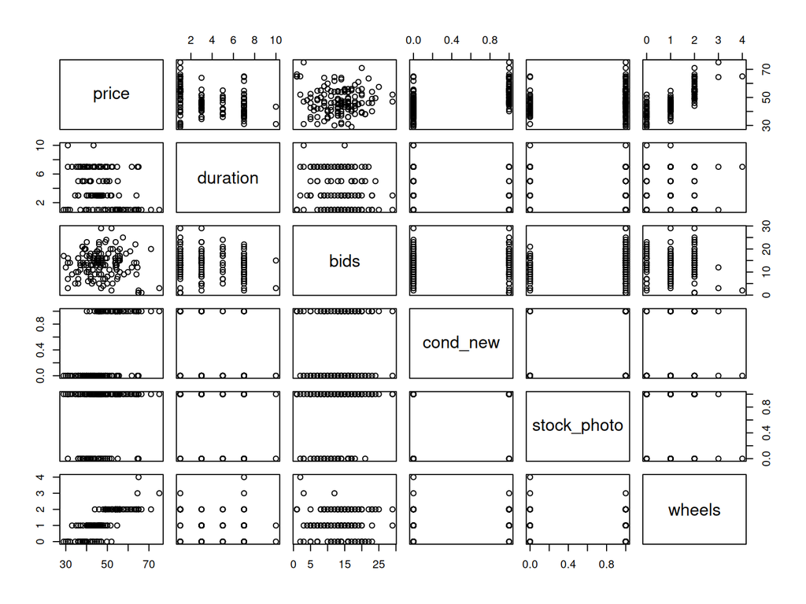

```r
plot(mario)
```

# Checking variance & residuals

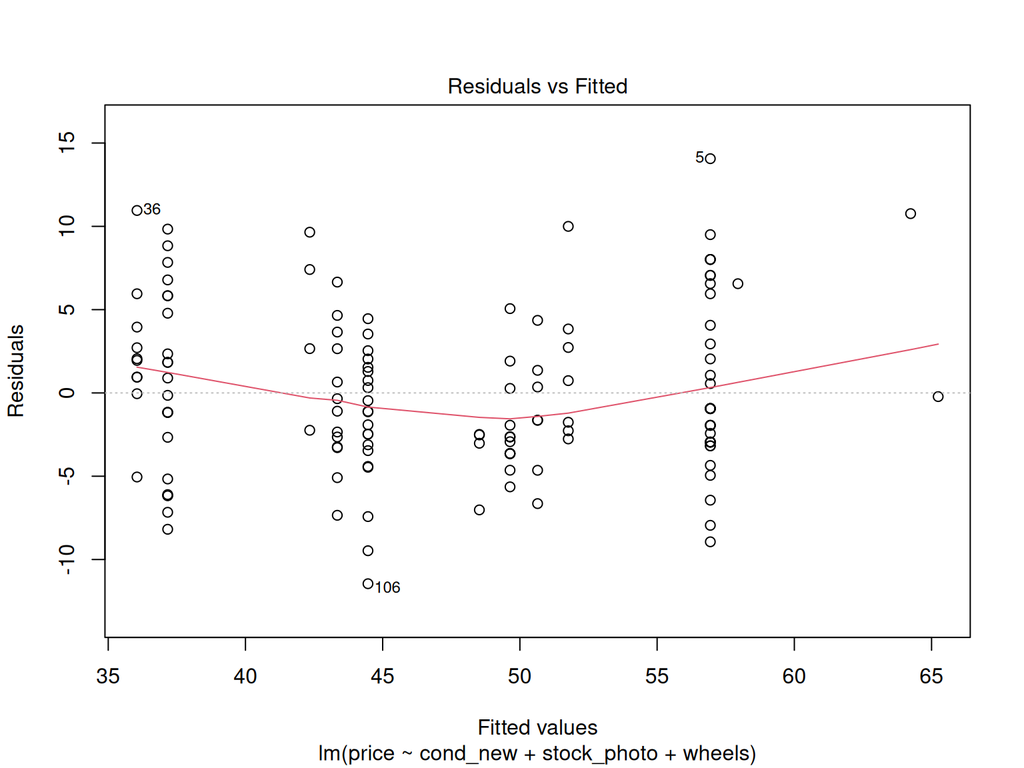

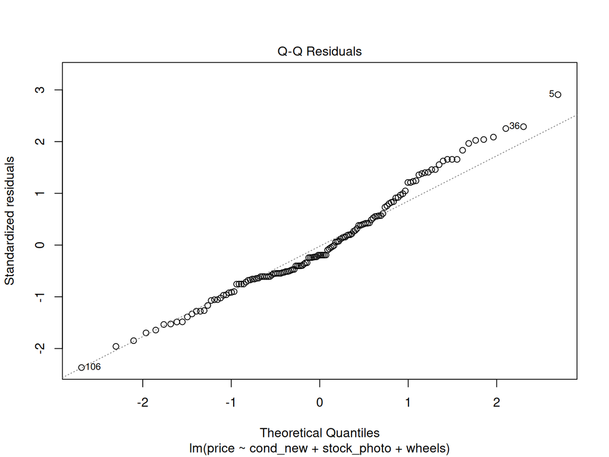

```r
plot(mario_lm, which = 1:2)
```